# Bootstrapping

# 1 Estimation of US male height

Suppose we want to estimate the average height of men in the U.S.

We can use data from the [BRFSS (2016)](https://www.cdc.gov/brfss/annual_data/annual_2016.html):

“The Behavioral Risk Factor Surveillance System (BRFSS) is the nation’s premier system of health-related telephone surveys that collect state data about U.S. residents regarding their health-related risk behaviors, chronic health conditions, and use of preventive services.”

```r
male_heights <- read_csv("https://raw.githubusercontent.com/apreshill/ohsu-basic-stats/master/data/male_heights.csv")
```

## 1.1 EDA

Height is in self-reported height in centimeters.

- How many unique heights are there?
- How many men were 103 cm?
- How about 231 cm?

## 1.2 Estimate

What is the `mean` and `sd` of male heights?

## 1.3 Quantify precision

At this point we have an estimate of the average adult male height. We’d like to know how accurate this estimate is, and how precise. In the context of estimation, these words have a technical distinction:

“Given a set of data points from repeated measurements of the same quantity, the set can be said to be precise if the values are close to each other, while the set can be said to be accurate if their average is close to the true value of the quantity being measured.”

Usually accuracy is what we really care about, but it’s hard to measure accuracy unless you know the true value. And if you knew the true value, you wouldn’t have to estimate it in the first place.

Quantifying precision is not as useful, but it is much easier. Here’s one way to do it:

- Use the data you have to make a model of the population.
- Use the model to simulate the **random** data collection process.
- Use the simulated data to compute an estimate.
- Repeat steps 1-3 and collect the results.

To model the population, we’ll use resampling; that is, we will treat the observed measurements as if they were taken from the entire population, and we will draw random samples from them.

We sample with replacement, which means that some measurements might be chosen more than once, and some might not be chosen at all. (If we sample without replacement, the resampled data is always identical to the original, so that’s no good.)

```r
males <- male_heights %>%
  tally() %>%
  pull()
set.seed(2051)
mh_resample1 <- male_heights %>%
  sample_n(size = males, replace = TRUE)
```

In `mh_resample1`:

- How many men were 103 cm?
- How about 231 cm?
- Try setting seed to `1903` and create `mh_resample2`, answer the two questions again.
- Try setting seed to `1701` and create `mh_resample3`, answer the two questions again.

If we wanted to use `infer` instead to generate a SINGLE replicate or resample, we would use:

```r
library(infer)
set.seed(1701)
mh_resample3 <- male_heights %>%
  specify(response = HTM4) %>%
  generate(reps = 1, type = "bootstrap")
```

Now let’s `generate` 1,000 replicates, `calculate` the mean for each replicate, and make a histogram to show the distribution of all the 1,000 calculated means.

The width of this distribution shows how much the results vary from one experiment to the next.

We can quantify this variability by computing the standard deviation of the sampling distribution, which is called “standard error”. The standard error is the standard deviation of the sampling distribution.

We can also summarize the sampling distribution with a “confidence interval”, which is a range that contains a specified fraction, like 95%, of the values in `mh_means`.

The central 95% confidence interval is between the 2.5th and 97.55th percentiles of the sampling distribution.

You can also use `infer` to plot a histogram and shade the 95% confidence interval.

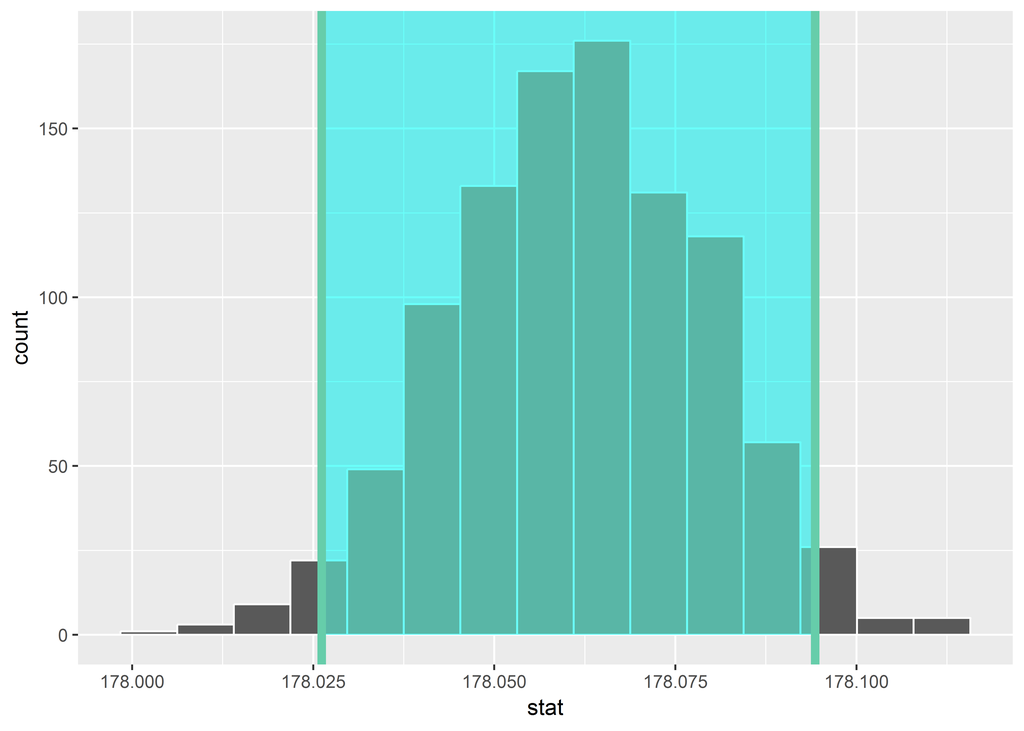

You can see that 95% of the data stored in the `stat` variable in `mh_means` falls between the two endpoints with 2.5% to the left outside of the shading and 2.5% to the right outside of the shading. The cut-off points that provide our range are shown with the darker lines.